# Association diagrams for loglinear models

friendly

2023-02-08

## Basic ideas

Exploring the idea of using **association diagrams** for fitting and understanding relationships in high-way categorical data fitted as loglinear models. The essential idea is to try to connect model fit statistics with some visual representation as network diagrams, with nodes representing variables in a model and edges representing pairwise associations.

One realization of this would be a function, say `assocgraph()` that takes a loglinear model (from `MASS::loglm()`, or `glm(, family=poisson)`) and builds the graph object corresponding to **all two-way** terms in the model. A weight for each edge could be obtained using the deviance for that pair, found using either

- `MASS::dropterm()` – the change in model fit (deviance, LRT) due to dropping each term from a given model.
- `MASS::addterm()` – the change in model fit (deviance, LRT) due to adding each two-way association to the model of mutual independence.

### Graph packages:

- [`igraph`](https://igraph.org/r/) seems to be the base package for constructing & drawing network diagrams
- [`tidygraph`](https://tidygraph.data-imaginist.com/) provides a tidy API for graph/network manipulation
- [`ggraph`](https://ggraph.data-imaginist.com/) uses such graph datasets to draw them better, within the `ggplot2` framework.
- See also the [CRAN Task View on Graphical Models](https://cran.r-project.org/web/views/GraphicalModels.html),

### Tutorials

- [Graph analysis using the tidyverse](https://rviews.rstudio.com/2019/03/06/intro-to-graph-analysis/)
- [Introduction to Network Analysis with R](https://www.jessesadler.com/post/network-analysis-with-r/) – a nice tutorial on using these packages.

### Model fitting:

- `MASS::dropterm()` tries fitting all models that differ from the current model by dropping a single term, maintaining marginality.
- `MASS::addterm()` tries fitting all models that differ from the current model by adding a single term, maintaining marginality.
- `vcdExtra::Kway()` fits a collection of loglinear models for all 0-, 1-, 2-, … way associations in a K-way table
- `vcdExtra::seq_loglm()` fits various sequential models to the 1-, 2-, … n-way marginal tables, corresponding to a variety of types of loglinear models.

## Load packages

```r
library(vcdExtra)
library(MASS)     # for loglm(), dropterm()
library(igraph)   # Network Analysis and Visualization
library(ggraph)   # An Implementation of Grammar of Graphics for Graphs and Networks
library(tidygraph)
library(ggplot2)
library(dplyr)
```

## Load the data

This example uses the `DaytonSurvey` dataset, representing a $2^5$ table.

```r
data (DaytonSurvey, package = "vcdExtra")
head(DaytonSurvey)
```

```
##   cigarette alcohol marijuana    sex  race Freq
## 1       Yes     Yes       Yes female white  405
## 2        No     Yes       Yes female white   13
## 3       Yes      No       Yes female white    1
## 4        No      No       Yes female white    1
## 5       Yes     Yes        No female white  268
## 6        No     Yes        No female white  218
```

View as a frequency table

```r
Dayton_tab <- xtabs(Freq ~ ., data=DaytonSurvey)
structable(cigarette + alcohol + marijuana ~ sex + race, data=Dayton_tab)
```

```
##              cigarette Yes              No
##              alcohol   Yes      No     Yes      No
##              marijuana Yes  No Yes  No Yes  No Yes  No
## sex    race
## female white           405 268   1  17  13 218   1 117
##        other            23  23   0   1   2  19   0  12
## male   white           453 228   1  17  28 201   1 133
##        other            30  19   1   8   1  18   0  17
```

## Model survey

A quick survey of loglm models with all 0, 1, 2, 3 way terms

```r
mods <- Kway(Freq ~ cigarette + alcohol + marijuana + sex + race,
             data = DaytonSurvey,
             order = 3)
```

## Test nested models

Compare varying order of associations among variables

```r
anova(mods, test="Chisq")
```

```
## Analysis of Deviance Table
##
## Model 1: Freq ~ 1
## Model 2: Freq ~ cigarette + alcohol + marijuana + sex + race
## Model 3: Freq ~ cigarette + alcohol + marijuana + sex + race + cigarette:alcohol +
##     cigarette:marijuana + cigarette:sex + cigarette:race + alcohol:marijuana +
##     alcohol:sex + alcohol:race + marijuana:sex + marijuana:race +
##     sex:race
## Model 4: Freq ~ cigarette + alcohol + marijuana + sex + race + cigarette:alcohol +
##     cigarette:marijuana + cigarette:sex + cigarette:race + alcohol:marijuana +
##     alcohol:sex + alcohol:race + marijuana:sex + marijuana:race +
##     sex:race + cigarette:alcohol:marijuana + cigarette:alcohol:sex +
##     cigarette:alcohol:race + cigarette:marijuana:sex + cigarette:marijuana:race +
##     cigarette:sex:race + alcohol:marijuana:sex + alcohol:marijuana:race +
##     alcohol:sex:race + marijuana:sex:race
##   Resid. Df Resid. Dev Df Deviance Pr(>Chi)
## 1        31     4818.1
## 2        26     1325.9  5   3492.1   <2e-16 ***
## 3        16       15.3 10   1310.6   <2e-16 ***
## 4         6        5.3 10     10.1   0.4345
## ---
## Signif. codes:  0 '***' 0.001 '**' 0.01 '*' 0.05 '.' 0.1 ' ' 1
```

## Summarize these models

`LRstats()` gives AIC, BIC and LR Chisq tests.

```r
LRstats(mods)
```

```
## Likelihood summary table:
##           AIC    BIC LR Chisq Df Pr(>Chisq)
## kway.0 4956.3 4957.8   4818.1 31     <2e-16 ***
## kway.1 1474.2 1483.0   1325.9 26     <2e-16 ***
## kway.2  183.6  207.0     15.3 16     0.4999
## kway.3  193.5  231.6      5.3  6     0.5094
## ---
## Signif. codes:  0 '***' 0.001 '**' 0.01 '*' 0.05 '.' 0.1 ' ' 1
```

## Direct fitting

Focusing on the all-twoway model, this could have been fitted directly using the model formula notation.

```r
mod.2way <- loglm(Freq ~ (cigarette + alcohol + marijuana + sex + race)^2,
                 data = DaytonSurvey)
```

## The all two-way model

```r
mods$kway.2
```

```
##
## Call:  glm(formula = Freq ~ cigarette + alcohol + marijuana + sex +
##     race + cigarette:alcohol + cigarette:marijuana + cigarette:sex +
##     cigarette:race + alcohol:marijuana + alcohol:sex + alcohol:race +
##     marijuana:sex + marijuana:race + sex:race, family = family,
##     data = data)
##
## Coefficients:
##             (Intercept)              cigaretteNo                alcoholNo
##                  5.9917                  -3.0683                  -5.7080
##             marijuanaNo                  sexmale                raceother
##                 -0.3938                   0.1310                  -2.8402
##   cigaretteNo:alcoholNo  cigaretteNo:marijuanaNo      cigaretteNo:sexmale
##                  2.0538                   2.8596                   0.1096
##   cigaretteNo:raceother    alcoholNo:marijuanaNo        alcoholNo:sexmale
##                 -0.1354                   2.9907                   0.2483
##     alcoholNo:raceother      marijuanaNo:sexmale    marijuanaNo:raceother
##                  0.5073                  -0.3176                   0.3731
##       sexmale:raceother
##                  0.1456
##
## Degrees of Freedom: 31 Total (i.e. Null);  16 Residual
## Null Deviance:       4818
## Residual Deviance: 15.34     AIC: 183.6
```

## Find deviance / AIC for all pairwise terms.

We can use these as weights for the links in an association graph

```r
(DT <- dropterm(mods$kway.2))
```

```
## Single term deletions
##
## Model:
## Freq ~ cigarette + alcohol + marijuana + sex + race + cigarette:alcohol +
##     cigarette:marijuana + cigarette:sex + cigarette:race + alcohol:marijuana +
##     alcohol:sex + alcohol:race + marijuana:sex + marijuana:race +
##     sex:race
##                     Df Deviance    AIC
## <none>                    15.34 183.58
## cigarette:alcohol    1   201.20 367.44
## cigarette:marijuana  1   513.47 679.71
## cigarette:sex        1    16.32 182.56
## cigarette:race       1    15.78 182.02
## alcohol:marijuana    1   106.96 273.20
## alcohol:sex          1    18.72 184.96
## alcohol:race         1    20.32 186.56
## marijuana:sex        1    25.16 191.40
## marijuana:race       1    18.93 185.17
## sex:race             1    16.18 182.42
```

Remove the `<none>` model. All we want is the stats for dropping each two-way term.

```r
DT <- DT[-1,]
```

## Exploring `igraph`

Exploring the ways to use the `igraph` package to visualize associations in multi-way tables.  
Create the full graph of all two-way associations

```r
full <- make_full_graph(5)
```

## Functions `V()` and `E()`

`igraph::V()` and `igraph::E()` are used both to display the node and edge information in a graph, or to assign attributes to them.

vertexes (nodes):

```r
V(full)
```

```
## + 5/5 vertices, from 87cb913:
## [1] 1 2 3 4 5
```

edges:

```r
E(full)
```

```
## + 10/10 edges from 87cb913:
##  [1] 1--2 1--3 1--4 1--5 2--3 2--4 2--5 3--4 3--5 4--5
```

## `plot()`

`igraph::plot()` plots the nodes and edges

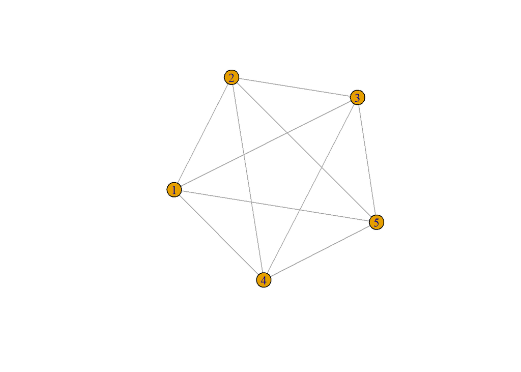

```r
plot(full)
```

### Give nodes the names of the variables

The `name` attribute of nodes is special in `igraph`.

For later use, this step assumes that the names assigned to the nodes are in the *same order* as those used in the `loglm()` model.

```r
V(full)$name <- names(DaytonSurvey)[1:5]

V(full)
```

```
## + 5/5 vertices, named, from 87cb913:
## [1] cigarette alcohol   marijuana sex       race
```

```r
E(full)
```

```
## + 10/10 edges from 87cb913 (vertex names):
##  [1] cigarette--alcohol   cigarette--marijuana cigarette--sex
##  [4] cigarette--race      alcohol  --marijuana alcohol  --sex
##  [7] alcohol  --race      marijuana--sex       marijuana--race
## [10] sex      --race
```

### Node colors

make colors correspond to outcomes vs. demographic variables

```r
V(full)$color <- c(rep("orange", 3),
                   rep("lightblue", 2))
```

### Edge statistics

You can also assign arbitrary variables to the edges.

Here, assign deviance and AIC as potential weights for edges

```r
E(full)$deviance <- DT$Deviance
E(full)$aic      <- DT$AIC

E(full)
```

```
## + 10/10 edges from 87cb913 (vertex names):
##  [1] cigarette--alcohol   cigarette--marijuana cigarette--sex
##  [4] cigarette--race      alcohol  --marijuana alcohol  --sex
##  [7] alcohol  --race      marijuana--sex       marijuana--race
## [10] sex      --race
```

## Make edge width ~ deviance

This is the key step for this visualization. For generality, need a better scheme to translate deviance into the width of the edges.

```r
E(full)$width <- E(full)$deviance/25
```

## Explore the `igraph` object

There are lots of `igraph` functions to get details of a given graph object.

```r
full[]
```

```
## 5 x 5 sparse Matrix of class "dgCMatrix"
##           cigarette alcohol marijuana sex race
## cigarette         .       1         1   1    1
## alcohol           1       .         1   1    1
## marijuana         1       1         .   1    1
## sex               1       1         1   .    1
## race              1       1         1   1    .
```

```r
edge.attributes(full)
```

```
## $deviance
##  [1] 201.19931 513.47218  16.31718  15.78347 106.95800  18.71695  20.32086
##  [8]  25.16101  18.92894  16.17921
##
## $aic
##  [1] 367.4376 679.7105 182.5555 182.0217 273.1963 184.9552 186.5591 191.3993
##  [9] 185.1672 182.4175
##
## $width
##  [1]  8.0479724 20.5388872  0.6526874  0.6313387  4.2783199  0.7486780
##  [7]  0.8128344  1.0064403  0.7571574  0.6471683
```

`ends()` delivers the edges as two-column data.frame

```r
ends(full, es=E(full), names=T)
```

```
##       [,1]        [,2]
##  [1,] "cigarette" "alcohol"
##  [2,] "cigarette" "marijuana"
##  [3,] "cigarette" "sex"
##  [4,] "cigarette" "race"
##  [5,] "alcohol"   "marijuana"
##  [6,] "alcohol"   "sex"
##  [7,] "alcohol"   "race"
##  [8,] "marijuana" "sex"
##  [9,] "marijuana" "race"
## [10,] "sex"       "race"
```

## Plot

Plot the all two-way model with edge `width ~ deviance`. This uses the `E(full)$width` and `V(full)$color` attributes assigned above. Other attributes can be assigned with optional arguments.

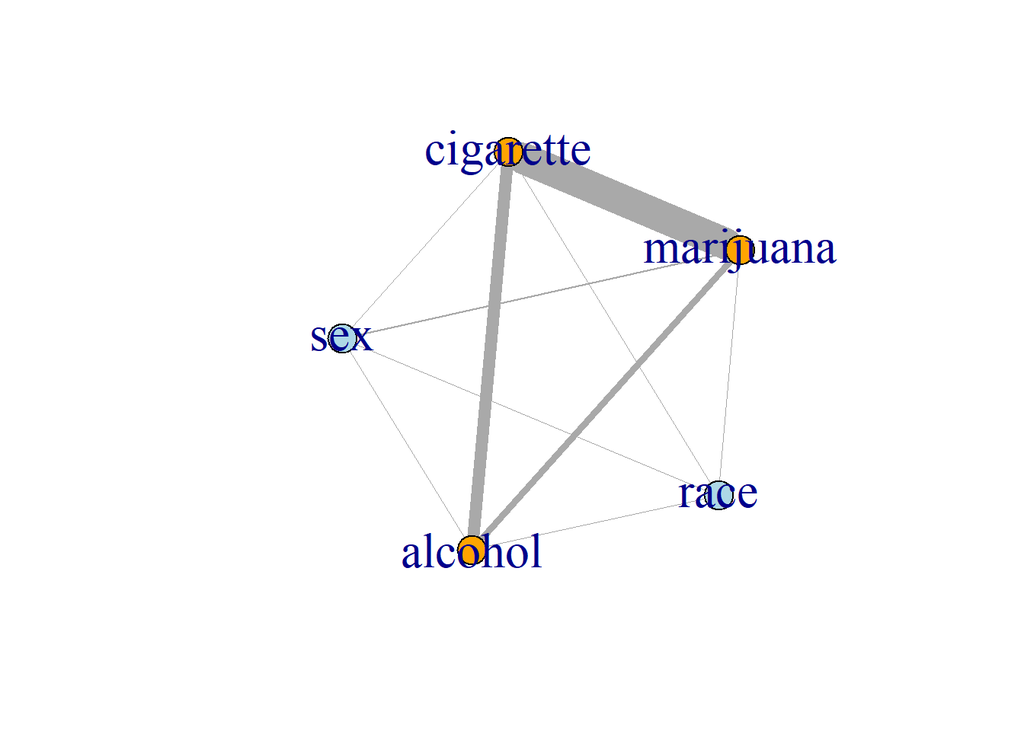

```r
set.seed(1234)
plot(full, vertex.label.cex=2)
```

## Try to do this using `ggraph` ???

This doesn’t work …

```r
# ggraph(full) +
#   geom_edge_link(aes(width = DT$Deviance[-1]/25)) +
#   geom_node_point()
```